**MULTIPLE**

**SCLEROSIS MSJ**

**JOURNAL**

**Introduction**

Multiple sclerosis (MS) is an inflammatory disorder

that is characterized by focal damage to white matter,

oligodendrocyte cell death and loss of myelin.

Clinically available therapies reduce relapses but they

do not effectively slow irreversible damage, such as

neuronal and axonal injury, which occurs during both

the early and late phases of the disease.<sup>1</sup> Cumulative

axonal and neuronal injury is thought to be a major

contributor to MS progression,<sup>2,3</sup> which will eventu-

ally affect the majority of people with MS.<sup>4</sup> Methods

that slow or stop axonal injury and brain atrophy are

valuable therapeutic targets.<sup>5–7</sup>

Oxidative stress (OS), the overabundance of reactive

oxygen species (ROS) or reactive nitrogen species

(RNS), is one contributor to neuronal and axonal injury

in MS.<sup>8,9</sup> When there is a preponderance of ROS/RNS

in the brain and spinal cord that cannot be adequately

eliminated by endogenous mechanisms, neural tissue

becomes injured. Evidence for a role of ROS/RNS in

the pathology of MS is offered by the accumulation of

oxidized lipids, nucleotides or proteins. Active and

expanding MS lesions express increased oxidized lipid

and nucleotide species, especially in degenerating axons

and damaged oligodendrocytes.<sup>10,11</sup> Moreover, there is

an upregulation of nitric oxide synthase and nicotina-

mide adenine dinucleotide phosphate (NADPH) oxi-

dase in MS lesions,<sup>12,13</sup> which are enzymes that produce

nitric oxide and superoxide, respectively. Together,

nitric oxide and superoxide are the important contribu-

tors to focal axonal swelling and degeneration.<sup>14</sup>

**Over-the-counter anti-oxidant therapies for use**

**in multiple sclerosis: A systematic review**

**Jason R. Plemel*****, Camille A. Juzwik*****, Curtis A. Benson*****, Michael Monks,**

**Chelsea Harris and Michelle Ploughman**

*These authors contributed equally

*Abstract*

**Background:** Anti-oxidant compounds that are found in over-the-counter (OTC) supplements and foods

are gaining interest as treatments for multiple sclerosis (MS). They are widely used by patients, some-

times without a clear evidence base.

**Objective:** We conducted a systematic review of animal and clinical research to determine the evidence

for the benefits of OTC anti-oxidants in MS.

**Methods:** Using predefined criteria, we searched key databases. Two authors scrutinized all studies

against inclusion/exclusion criteria, assessed study risk-of-bias and extracted results.

**Results:** Of the 3507 titles, 145 met criteria and included compounds, α(alpha)-lipoic acid (ALA), anti-

oxidant vitamins, *Ginkgo biloba*, quercetin, resveratrol and epigallocatechin-3-gallate (ECGC). The

strongest evidence to support OTC anti-oxidants was for compounds EGCG and ALA in animal models;

both consistently showed anti-inflammatory/anti-oxidant effects and reduced neurological impairment.

Only vitamin E, *Ginkgo biloba* and ALA were examined for efficacy in pilot clinical trials with either

conflicting evidence or evidence of no benefit.

**Conclusion:** OTC anti-oxidants EGCG and ALA show the most consistent benefit, however only in

preclinical studies. There is no evidence that they alter MS relapses or progression. Future work should

focus on testing more of these therapies for clinical efficacy before recommending them to MS patients.

*Keywords:* Alpha lipoic acid, polyphenols, *Ginkgo biloba*, vitamins, oxidative stress, complementary,

alternative therapies

Date received: 4 February 2015; revised: 11 July 2015; accepted: 27 July 2015

Correspondence to:

**Dr Michelle Ploughman**

Recovery & Performance

Laboratory, Faculty of

Medicine, Memorial

University, Room 400, L.A.

Miller Centre, 100 Forest

Rd., St. John’s NL A1A 1E5,

Canada.

**michelle.ploughman@med.**

**mun.ca**

**Jason R. Plemel**

Department of Clinical

Neurosciences and the

Hotchkiss Brain Institute,

University of Calgary,

Canada

**Camille A. Juzwik**

Department of Neurology

and Neurosurgery, Montréal

Neurological Institute,

Canada

**Curtis A. Benson**

Neuroscience and Mental

Health Institute, University of

Alberta, Canada

**Michael Monks**

**Chelsea Harris**

**Michelle Ploughman**

Recovery & Performance

Laboratory, Memorial

University, Canada

*Topical Review*

Anti-oxidant drug therapies, diets, and supplements,

purported to counteract ROS and RNS cascades, are

available as over-the-counter (OTC) remedies yet

their benefits have not been proven. Most people with

MS reporting using an OTC supplement despite the

lack of a clear evidence base.<sup>15</sup> We undertook this

study to systematically and rigorously examine current

research findings on the effects of OTC anti-oxidant

supplements in animal models and clinical trials in

MS. Our aim was to translate research findings to MS

clinicians and to identify areas for future research.

**Methods**

*Search strategy*

With the assistance of a librarian expert in sys-

tematic reviews and using predefined search terms

(Table 1), we searched PubMed, CINAHL, PsychInfo, the

Cochrane Library, and the Central Register of Controlled

Clinical Trials, including all years up to 1 October 2013

(English language only). Clinical studies were included

if the participants had MS or the biological products

tested were from people with MS. Animal studies were

included if a disease, similar to MS, was induced in ani-

mals and included at least behavioral findings.

*Data extraction and synthesis*

Following Preferred Reporting Items for Systematic

Reviews and Meta-Analyses (PRISMA) guidelines,<sup>16</sup>

and after duplicates were removed, we merged titles

retrieved across search databases. At the title, abstract,

and manuscript levels of the search, two authors eval-

uated inclusion status independently and if the authors

disagreed, the article was included. Data extraction

and synthesis was conducted on manuscripts that

were categorized by compound tested. Reference lists

of included articles were hand-searched and two

authors scrutinized all titles against inclusion criteria.

The data from all studies were extracted into article

summary spreadsheets. In order to prevent inflation of

findings, we required at least three studies testing a

specific compound of interest in order to be included.

Each study was assessed for risk-of-bias: the clinical

studies using the Cochrane Collaboration risk-of-bias

tool;<sup>17</sup> and animal studies using a combination of two

previously published checklists.<sup>18,19</sup>

**Results**

Our review resulted in 3507 titles, of which 400 were

reviewed at the manuscript level (Figure 1). Although

there were 12 studies examining uric acid, we did not

synthesize the findings since there are several recent

reviews as well as a clinical trial completed.<sup>20–22</sup>

Similarly, there is a recent Cochrane review that sum-

marizes the literature regarding polyunsaturated fatty

acids (PUFA).<sup>23</sup> Many compounds had fewer than three

studies, which were below our threshold for synthesis;

for example, chelation, polyamines, selenium, and oth-

ers (Figure 1). The final research articles were grouped

by category (polyphenols, anti-oxidant vitamins, alpha

lipoic acid (ALA), and *Ginkgo biloba*). A summary is

provided describing the extent of the research evidence

in polyphenols (luteolin, quercetin, curcumin, EGCG,

and resveratrol), anti-oxidant vitamins (A, C, and E),

*G. biloba* and ALA (Table 2). We found that evidence in

animal models consistently supported the benefits of

EGCG and ALA. The only evidence supporting use of

OTC anti-oxidants among people with MS was in

*G. biloba* and ALA, and that evidence was conflicting.

*Polyphenols*

Polyphenols are the most abundant dietary anti-

oxidants, occurring naturally in fruits, vegetables, and

cereals.<sup>24</sup> They are believed to function through their

**Table 1.** Search terms.

Area

Search terms

Pathology*

Multiple sclerosis, chronic neurological disease, central nervous system (CNS), inflammation,

demyelination, remyelination, axonal degeneration, cortical atrophy, virus demyelination,

randomized controlled trials, clinical controlled trials, animal model, model, experimental

autoimmune encephalomyelitis (EAE), cuprizone, focal demyelination

Intervention*

Anti-oxidant, OS, ROS, RNS, hydroxyl radicals, peroxynitrite, superoxide, metal chelators,

iron chelators, dietary intervention, diet plan, dietary supplements, dietary management, anti-

inflammatory, poly-unsaturated fatty acids (PUFAs), selenium, blueberries, green tea, *Ginkgo*

*biloba* extracts, coenzyme Q10, turmeric, curcumin, vitamin C, vitamin E, vitamin A, phenolic,

polyphenol, flavonoid, carotenoid

* Titles were included if the title or keywords included at least one term from the ‘pathology terms’ list and one term from the ‘inter-

vention terms’.

anti-oxidant and radical scavenging activities.<sup>25</sup> Our

review included 15 studies examining five com-

pounds classified as polyphenols, where some studies

examine more than one compound: quercetin,<sup>26–29</sup>

luteolin,<sup>26,29,30</sup> curcumin,<sup>29,31,32</sup> resveratrol,<sup>33–36</sup> and

epigallocatechin-3-gallate (EGCG).<sup>37–40</sup> Details of the

included studies are found in Supplementary Table 3

and assessment of risk-of-bias in Supplementary

Figure 2(a) and (b).

*Quercetin.* There were three animal studies examining

quercetin in EAE,<sup>26,27,29</sup> and one *ex vivo* assessment

from MS patients.<sup>28</sup> When quercetin was administered

by intraperitoneal (i.p.) injection, EAE severity score

was less severe, which was associated with decreased

immune cell infiltrates in the spinal cord.<sup>26,27</sup> However,

when administered orally, mice showed no improve-

ment.<sup>29</sup> In the single clinical study, Peripheral blood

mononuclear cells (PBMCs) from RR-MS patients

and healthy controls were treated with quercetin or

quercetin plus the drug interferon-β (IFN-β) to exam-

ine potentially synergistic effects, but nothing conclu-

sive can be drawn as the baseline effect of IFN-β alone

was not included.<sup>28</sup>

*Luteolin.* In the three studies (two in animals and one

clinical study) examining luteolin, we see conflicting

results.<sup>26,29,30</sup> In EAE animals, luteolin either showed no

improvement<sup>29</sup> or a decrease in disease severity;<sup>26</sup> and

an *ex vivo* assessment of PBMCs from RR-MS patients

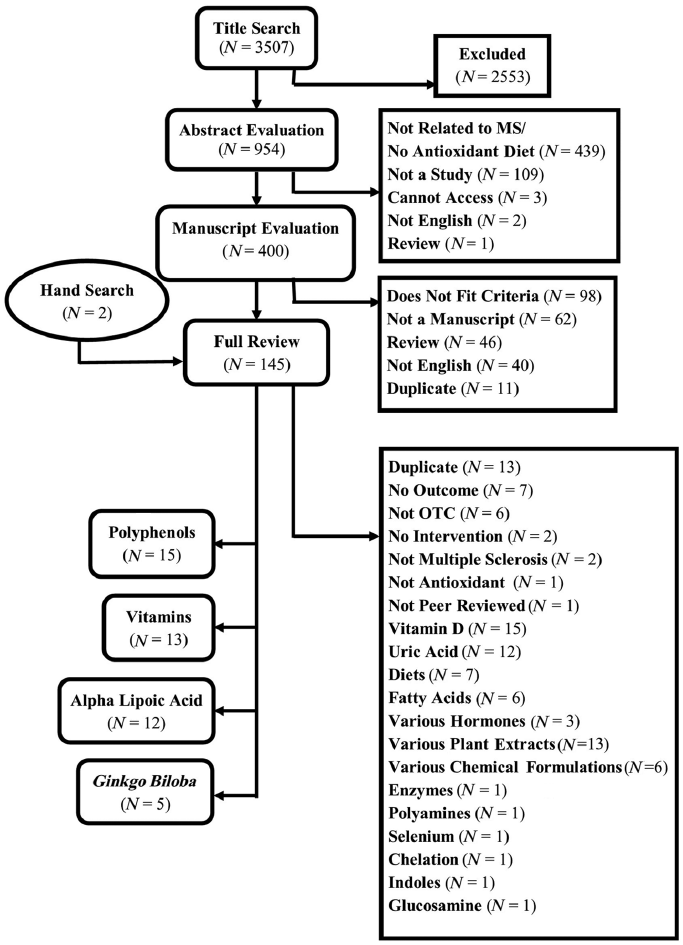

acids, and products that were not available OTC.

**Table 2.** Summary of research evidence.

Luteolin

Quercetin

Curcumin

EGCG

Resveratrol

Vitamin A

Vitamin C

Vitamin E

*Ginkgo*

*biloba*

Alpha lipoic

acid (ALA)

Broccoli*

Cranberries*

Tumeric*

Green tea*

Red grapes*

Spinach*

Red pepper*

Almonds*

Extract*

Organ meats*

Animal models

Anti-inflammatory/anti-

oxidant properties

 X

X

O

O

O

O

Decreased damage to

nervous system (e.g.

relapses)

O

O

O

 X

O

O

O

Reduced disease severity

 X

X

O

O

MS patients

Anti-inflammatory/anti-

oxidant properties

O

O

O

O

O

O

O

O

O

 X

Decreased relapses

O

O

O

O

O

O

O

O

O

O

Reduced disease

progression

O

O

O

O

O

O

O

X

 X

O

* Examples of natural sources of compounds. Most studies examined in this review tested purified extracts or synthesized products.  evidence to support; X evidence that there is no benefit; O no

evidence.

treated with luteolin plus IFN-β provide no conclusive

data as a critical control group was missing.<sup>30</sup>

*Curcumin.* Curcumin is the main ingredient of tur-

meric and a lipophilic compound that crosses mem-

branes easily, making it a promising oral therapy.<sup>41</sup>

The three studies reviewed all employed animal mod-

els that showed consistent anti-inflammatory bene-

fits.<sup>29,31,32</sup> It decreased the T cell production of

IFN-γ;<sup>29</sup> prevented the differentiation of T helper 1

(Th1) cells;<sup>31</sup> and decreased the amount of Th17-

differentiated cells.<sup>32</sup> As the included studies adminis-

tered curcumin before the onset of clinical symptoms,

only preventative effects were assessed.<sup>29,31,32</sup> One

clinical trial examining curcumin as an adjunct ther-

apy to IFN-β1a is in recruitment phase (clinicaltrials.

gov, NCT01514370).

*EGCG.* EGCG is the most abundant of the biologi-

cally active catechins present in green tea. Four stud-

ies examined the ability of purified EGCG (95%) to

decrease the severity of EAE disease (Table 2 and

Supplementary Table 3).<sup>37–40</sup> EGCG-fed animals con-

sistently showed decreased severity scores compared

to control-fed animals, which was associated with

suppressed immune cell infiltrates,<sup>37–39</sup> decreased

demyelination in the spinal cord,<sup>39,42</sup> and a decreased

production of inflammatory cytokines that promote

Th1 and Th17 differentiation.<sup>37,39,40</sup> Furthermore,

EGCG enhanced the viability and outgrowth of hip-

pocampal cells in vitro.<sup>37,38</sup> To date, there are six

ongoing trials investigating EGCG as an adjunct ther-

apy in MS listed on clinicaltrials.gov (NCT00525668,

NCT02011451,

NCT00799890,

NCT00836719,

NCT01451723, and NCT01417312). Most of these

studies focus on the safety and the neuroprotective

ability of EGCG by assessing levels of neuronal

marker *N*-acetyl aspartate, used to identify the num-

ber of neurons and their metabolism.

*Resveratrol.* Resveratrol is found predominantly in

grapes and red wine.<sup>43</sup> It is known to have poor bio-

availability, so most studies administer SRT501, a

pharmaceutical formulation of resveratrol that has

enhanced systemic absorption.<sup>33,43</sup> In four studies

reviewed (all in animal models), both resveratrol

and SRT501 consistently decreased EAE sever-

ity,<sup>33–36</sup> which coincided with reduced optic nerve

damage and prevention of retinal ganglion cell

loss.<sup>33,35</sup> Resveratrol did not alter the levels of infil-

trating immune cells into the spinal cord of EAE

animals, suggesting it functions through a neuropro-

tective mechanism;<sup>33–35</sup> though one group reported

decreased levels of peripheral pro-inflammatory

cytokines.<sup>36</sup>

*Anti-oxidant vitamins*

Vitamins A (β-carotene and retinol), C (ascorbic acid)

and E (α-tocopherol), having anti-oxidant properties,

were examined in 13 studies (animal models *n* = 4;

clinical *n* = 7; population wide *n* = 2).<sup>44–56</sup> Details of the

included studies are found in Supplementary Table 4

and risk-of-bias in Supplementary Figure 3(a) and (b).

*Vitamin A.* There was a single animal study<sup>55</sup> and two

small clinical studies from the same cohort examining

vitamin A.<sup>45,46</sup> Treatment of vitamin A following EAE

increased the number of animals without EAE symp-

toms.<sup>55</sup> The two clinical studies were small, with

fewer than 20 subjects treated for 6 months with

25,000 IU vitamin A, finding decreased peripheral

immune cell proliferation, but only when cells were

cultured with fetal calf serum and not when cultured

with human serum.<sup>46</sup> In the same cohort, vitamin A

treatment increased the inflammatory marker C-reac-

tive protein indicating that vitamin A may also induce

certain aspects of inflammation.<sup>45</sup> There is currently a

registered clinical trial of vitamin A (clinicaltrials.gov

01225289).

*Vitamin E.* Vitamin E is a group of fat-soluble anti-

oxidants that include tocotrienols and tocopherols.<sup>57</sup>

Vitamin E can decrease protein kinase C, an impor-

tant cellular signaling molecule;<sup>58</sup> it can also regulate

the inflammatory arachadonic acid cascade by

increasing cytosolic phospholipase A2 and cyclooxy-

genase activities.<sup>59</sup> In the animal studies, vitamin E

either protected myelin or promoted myelin regenera-

tion.<sup>44,53</sup> In a small cohort of people with MS, nine

subjects treated for 30 months, vitamin E alone did

not decrease annual relapse rate.<sup>50</sup> However, whether

annual relapse rate meaningfully captures the protec-

tive effects of an anti-oxidant therapy is unclear. No

studies examined measures of brain atrophy or lesion

accumulation.

*Vitamin combinations.* We found five clinical studies

that tested anti-oxidant combinations including vita-

mins A, C, or E<sup>47–50,52</sup> (Supplementary Table 4). In

one small clinical study (9–12 participants per treat-

ment arm), a mixture of several PUFAs, monosatu-

rated fatty acids, and saturated fatty acids along with

vitamin E and vitamin A significantly reduced relapse

rate compared to control.<sup>50</sup> The authors reported that

vitamin E was a necessary component in this combi-

nation; however, it is difficult to draw definitive con-

clusions. In population studies it was found that that

the levels of vitamin intake were not associated with

increased risk of MS or disease progression when

adjusted for age, time period, latitude of birthplace,

smoking, and total energy.<sup>51,56</sup>

*Alpha lipoic acid (ALA)*

Found in very small amounts in foods such as organ

meats, spinach, and broccoli, ALA is synthesized in

the liver and is considered to be a naturally-occurring

anti-oxidant.<sup>60</sup> ALA is a direct scavenger of free radi-

cals and acts indirectly as a metal chelator thereby

lessening free-radical damage.<sup>61</sup> Of the 12 studies

included in this review, one reported findings in both

humans and animals<sup>62</sup> and four examined the effects

of ALA supplements in people with MS or their blood

products from two samples of patients.<sup>62–65</sup> The

remaining preclinical studies utilized the EAE rodent

model.<sup>42,62,66–71</sup> Detailed information is found in

Supplementary Table 5 and risk-of-bias assessments

in Supplementary Figure 4(a) and (b).

In terms of the effects of ALA on anti-oxidant/inflam-

matory mediators, peripheral T cell activity in ALA-

specific studies showed conflicting results.<sup>42,69</sup>

Marracci et al. reported no effect of ALA on pro-

inflammatory T cells<sup>69</sup> while Wang et al. reported

suppression of CD<sup>+</sup> T cells obtained from ALA-

treated animals.<sup>42</sup> In five studies there was a consist-

ent reduction in T cell infiltration into the CNS with

ALA treatment: spinal cord,<sup>42,67,69,71</sup> optic nerve,<sup>66</sup> and

cerebellum.<sup>42,71</sup>

The six studies examining the effects of ALA on

mediators of inflammation, such as matrix metal-

lopedtidase-9 (MMP-9) or soluble cell adhesion mol-

ecule (ICAM), in animal models<sup>42,67,70</sup> and people

with MS,<sup>63,64,72</sup> reported varying results. In serum

obtained from people with MS, 1200 mg LA adminis-

tered daily for 14 days did not change serum levels of

MMP-9, TIMP-1, or soluble cell adhesion molecule

(ICAM).<sup>72</sup> However, Khalili and group reported sig-

nificant reductions in pro-inflammatory markers

IFN-γ, ICAM-1, TGF-β, and IL-4 after 12 weeks of

treatment.<sup>64</sup> Studies in animal models showed more

consistent beneficial findings. ALA treatment reduced

immunostimulators

MMP,

IFN-γ,

and

IL-4;<sup>70</sup>

increased endogenous PPAR-γ, which acts to counter-

act OS;<sup>42</sup> and reduced expression of ICAM in spinal

cord tissue.<sup>67</sup> Two animal studies reported dose-

dependent effects of ALA, with higher dosages (100

µg/ml versus 25 µg/ml) being more beneficial and

oral ingestion being less effective than injection.<sup>67,70</sup>

Effects of ALA on recovery and repair were evaluated

in two ways: quantification of demyelination and

axonal injury,<sup>66,69,70</sup> and behavioral/clinical neurologi-

cal impairment score. The three studies examining the

effects of ALA on demyelination and axonal damage

in optic nerve, spinal cord, and brain consistently

showed that ALA-treated EAE animals had reduced

damage in the CNS,<sup>66,69,70</sup> which was dependent on

timing and route of administration. ALA administered

by i.p. injection seven days or directly following

immunization protected axons from demyelination

and damage.<sup>66,69,70</sup> Delayed ALA administration

reduced damage to optic nerve but not as robustly as

immediate treatment.<sup>66</sup> Oral administration was only

protective when instituted immediately, but not

delayed, following EAE immunization.<sup>70</sup>

All eight studies examining the behavioral effects of

ALA in the EAE model showed reduced disease sever-

ity in ALA-treated animals.<sup>42,62,66–71</sup> There was no

change in Expanded Disease Severity Scale (EDSS)

score in the five studies among people with MS,

although the longest intervention was only 12

weeks.<sup>64,65</sup> Four animal studies showed both dosage

and timing effects: low dosages of less than 10 mg/kg/

day,<sup>69,71</sup> or delayed dosage<sup>70</sup> were of minimal benefit.

However, one study showed that both early and late

administration of ALA abolished the EAE-related

impairment during the 24 day length of the experi-

ment.<sup>66</sup> Yadav and group reported that EAE-related

impairment was correlated with serum levels of ALA

in EAE animals.<sup>62</sup> Importantly, two studies showed that

when ALA treatment is halted, impairments return.<sup>68,69</sup>

Study durations in EAE models were less than 40 days

so the long-term benefits are unknown. Furthermore,

the effects of ALA on MS progression, relapse, or

recovery have not been tested in people with MS,

although several trials are posted in clinicaltrials.gov

(02133664, 00676156, 01188811).

In all except one study<sup>70</sup> in animal models ALA was

delivered by injection. When comparing injection of

ALA to delivery in drinking water, injection was more

effective at reducing severity of disease and indicators of

inflammation. In humans, ALA was provided orally in

pill form and the most common side effects were gastro-

intestinal upset, malodorous urine, and rash.<sup>72</sup> In people

with MS, there was wide variability in absorption and

clearance of ALA between individuals.<sup>62</sup> Furthermore,

ALA obtained from different suppliers had different

rates of metabolism.<sup>62,72</sup> These findings make it difficult

to know how much ALA dosage is required in humans.

*Ginkgo biloba*

*Ginkgo biloba* (*G. biloba*) extract is obtained from

*G. biloba* tree leaves, and the commercially available

products contain a mixture of biologically active

compounds.<sup>73</sup> The percentage of each compound

within a *G. biloba* extract varies between suppliers;

however, the most common research formulation is

EGb-761, which contains approximately 24% flavone

glycosides, 7% proanthocyanidins, and 6% terpene

lactones.<sup>73</sup> Our search revealed five studies examin-

ing *G. biloba* in MS, all of which were clinical trials

focusing on cognitive outcomes. Our search revealed

no preclinical trials in animal models of MS. Three of

the clinical trials were placebo-controlled, adminis-

tering 240 mg of *G. biloba* daily,<sup>74–76</sup> and two of these

were from the same research group, in which a small

study was followed by a larger trial.<sup>75,76</sup> One open-

label trial was conducted using a dose of 240 mg per

day; however, one participant received a dose of 120

mg due to a history of gastritis.<sup>77</sup> Lastly, one paper

reanalysed data from a previously conducted placebo-

controlled study.<sup>78</sup> All of these studies used commer-

cially available *G. biloba*, but only two used the

EGb-761 formulation.<sup>74,75</sup> Details of the included

studies are found in Supplementary Table 4, and risk-

of-bias is outlined in Supplementary Figure 5.

Four of the clinical studies reviewed examined the

effects of *G. biloba* on cognitive impairment in MS with

making it difficult to compare results. In an eight week

open-label trial, MS subjects had significant improve-

ment on the Wechsler memory test after treatment.<sup>77</sup> A

placebo-controlled study conducted by Lovera et al.

demonstrated that eight weeks of *G. biloba* treatment

improved scores on the Stroop memory test, indicating

increased cognitive flexibility.<sup>76</sup> Using data derived

from their 2006 clinic study, Diamond and group

reported that the *G. biloba* treated group had enhanced

processing speed on the Visual Threshold Serial

Addition Test and emitted less verbal intrusions on the

California Verbal Learning Test compared to a placebo

group.<sup>78</sup> However the largest study examining *G. biloba*

in 120 persons with MS with 61 randomized to *G.*

*biloba* failed to show any benefit on cognitive func-

tion.<sup>75</sup> Despite minimal effects on impairment or disa-

All of the studies included in this review studied the

effects of *G. biloba* administered orally in capsule, 240

mg per day divided in either 2 or 4 doses, though the

commercial sources of the *G. biloba* extract varied

between studies. *G. biloba* was well tolerated in most

cases. In one study a few participants reported mild

nausea.<sup>77</sup> No severe adverse events related to *G. biloba*

were observed during the trials reviewed.

**Discussion**

In an effort to combat the OS associated with injury in

MS, researchers are exploring anti-oxidant therapies

to reduce MS pathology. Our review focused on a

subset of this research: readily-available dietary anti-

oxidant compounds available OTC. We did not include

compounds that were examined in fewer than three

studies such as chelation, glucosamine, selenium, and

others. We also did not review compounds that had

already been subjected to rigorous review and synthe-

sis: uric acid<sup>20–22</sup> or PUFAs.<sup>23</sup> The largest body of

*biloba*, and ALA were examined in people with MS

with either conflicting evidence or evidence of no ben-

efit (Table 2). The strongest evidence to support OTC

anti-oxidants was for compounds EGCG and ALA in

animal models; both compounds consistently showed

anti-inflammatory/anti-oxidant

effects,

decreased

damage to the nervous system along with reduced neu-

rological impairment (Table 2).

*Optimal outcomes to assess the benefits of anti-*

*oxidants*

There was a paucity of mechanistic outcomes in the

studies included in this review. We found the reduc-

tion of pro-inflammatory markers as a common fea-

ture among animal studies, but the direct cause of the

reduced inflammation was more often undetermined.

Furthermore, considering that OTC anti-oxidants are

purported to provide neuroprotection and repair, there

were no studies that examined longer term outcomes

such as reduced lesion accumulation or disability pro-

gression. With the ongoing degeneration that is asso-

ciated with progressive MS and the presence of OS at

sites of degeneration,<sup>2,8,9,79,80</sup> determining the utility

of anti-oxidant therapies to protect neural tissue or

promote repair is a major research gap. In this review,

we found that only EGCG,<sup>37,38</sup> vitamin E,<sup>44,53</sup> reserva-

trol,<sup>33,35</sup> and ALA<sup>66,69,70</sup> promoted remyelination and/

or protected neurons from inflammatory-mediated

damage (in animal models). Resveratrol consistently

provided neuroprotection in EAE, though this was

independent of any anti-inflammatory benefits.<sup>33,35</sup>

Clinical studies included in this review provided

short term outcomes (predominantly 12 weeks post-

treatment) with no effects of OTC anti-oxidants on

the disease course (EDSS score). If it is purported that

anti-oxidants convey their benefits by interfering with

the inflammatory cascade and preventing axonal

damage then longer term outcomes, such as lesion

accumulation, number of relapses, or recovery post-

relapse, should be included in future studies. In other

neurodegenerative diseases, for example, vitamin E

for six months to four years significantly slowed

functional decline among people with Alzheimer’s

disease.<sup>81</sup> There are also opportunities to develop new

degenerative models that exhibit ROS-related nerv-

ous system injury to test potentially neuroprotective

compounds.<sup>82</sup>

*Translating preclinical results to clinical trials*

Patients with MS likely ingest OTC anti-oxidants,

and all the clinical studies we reviewed used oral

administration. However, in most animal studies,

anti-oxidant compounds were administered by either

subcutaneous or i.p. injection, making it challenging

to translate to the clinical setting. At least with ALA

treatment of EAE, injection was superior to oral

administration.<sup>26,29,70</sup> For other compounds, direct

administration into the blood may not always improve

bioavailability; passage through the gastrointestinal

tract could be needed to see any beneficial effects.<sup>83</sup>

Several studies showed that absorption of the product

varied extensively between individuals and by prod-

uct formulation, such as ALA<sup>62,72</sup> and *G. biloba*.<sup>84</sup>

Still, bioavailability in the circulation does not neces-

sarily mean that compounds can affect the CNS. For

many of the compounds studied, it was unclear

whether they crossed the blood-brain barrier to the

site of their potential action. More studies examining

pharmacokinetics particularly blood-brain barrier

penetration, are required.<sup>84–86</sup>

Another key concern for the safety of people with MS

is toleration of anti-oxidant diets and supplements.

Our findings suggest that in both humans and ani-

mals, anti-oxidant products were reasonably toler-

ated. Studies did not report animal mortality related to

the intervention; and side effects experienced in clini-

cal trials were mild, such as gastrointestinal upset (*G.*

*biloba* 240 mg/day, ALA 1200 mg/day).

*Improving the quality of anti-oxidant research*

*in MS*

We assessed risk-of-bias using validated tools for

both the clinical studies and studies involving animal

models. We identified four areas for improvement for

future research. In addition to mode of compound

administration and duration of assessment mentioned

above, we noted that about half of the protocols did

not include blinding of assessors, and there was exten-

sive use of subjective rating scales of behavioral out-

comes. Since the behavioral and clinical measures

require subjectivity by the assessor, this is a concern.

As discussed by researchers in other fields, strength-

ening preclinical research methodology facilitates

knowledge translation.<sup>18,19</sup>

In summary, our review provides a preliminary frame-

work for the benefits of anti-oxidant diets in alleviat-

ing the progression of MS and describes key areas of

improvement for future animal and clinical studies.

Although some preclinical results are promising, at

this time, the evidence suggests that OTC anti-oxi-

dants do not alter the disease in people with MS.

**Conflict of interest**

None declared.

**Funding**

This study was supported by the endMS Research

Training Network, Scholar Program for Researchers in

Training (SPRINT) and the MS Society of Canada.

JRP is supported by the Donna Joan Oxford Postdoctoral

Fellowship Award from the Multiple Sclerosis Society

of Canada and by postdoctoral fellowships awards

from the Canadian Institutes of Health Research

(CIHR) and T. Chen Fong. CJ is supported by a CIHR

Vanier Graduate Canada Scholarship and by fellowship

awards from the Multiple Sclerosis Society of Canada

and the CIHR Neuroinflammation Training Program.

CB is supported by a Multiple Sclerosis Society of

Canada graduate fellowship.

**References**

1. Bjartmar C and Trapp BD. Axonal degeneration and

progressive neurologic disability in multiple sclerosis.

*Neurotox Res* 2003; 5: 157–164.

2. Coles AJ, Wing MG, Molyneux P, et al. Monoclonal

antibody treatment exposes three mechanisms

underlying the clinical course of multiple sclerosis.

*Ann Neurol* 1999; 46: 296–304.

3. Metz I, Lucchinetti CF, Openshaw H, et al.

Autologous haematopoietic stem cell transplantation

fails to stop demyelination and neurodegeneration in

multiple sclerosis. *Brain* 2007; 130: 1254–1262.

4. Scalfari A, Neuhaus A, Degenhardt A, et al. The

natural history of multiple sclerosis: A geographically

based study 10: Relapses and long-term disability.

*Brain* 2010; 133: 1914–1929.

5. Trapp BD and Stys PK. Virtual hypoxia and chronic

necrosis of demyelinated axons in multiple sclerosis.

*Lancet Neurol* 2009; 8: 280–291.

6. Geurts JJ, Stys PK, Minagar A, et al. Gray matter

pathology in (chronic) MS: Modern views on an early

observation. *J Neurol Sci* 2009; 282: 12–20.

7. Rudick RA and Trapp BD. Gray-matter injury in

multiple sclerosis. *N Engl J Med* 2009; 361: 1505–

1506.

8. Franklin RJ, ffrench-Constant C, Edgar JM, et al.

Neuroprotection and repair in multiple sclerosis. *Nat*

*Rev Neurol* 2012; 8: 624–634.

9. Smith KJ, Kapoor R and Felts PA. Demyelination:

The role of reactive oxygen and nitrogen species.

*Brain Pathol* 1999; 9: 69–92.

10. Haider L, Fischer MT, Frischer JM, et al. Oxidative

damage in multiple sclerosis lesions. *Brain* 2011;

134: 1914–1924.

11. Cross AH, Manning PT, Keeling RM, et al.

Peroxynitrite formation within the central nervous

system in active multiple sclerosis. *J Neuroimmunol*

1998; 88: 45–56.

12. Liu JS, Zhao ML, Brosnan CF, et al. Expression of

inducible nitric oxide synthase and nitrotyrosine in

multiple sclerosis lesions. *Am J Pathol* 2001; 158:

2057–2066.

13. Fischer MT, Sharma R, Lim JL, et al. NADPH

oxidase expression in active multiple sclerosis

lesions in relation to oxidative tissue damage and

mitochondrial injury. *Brain* 2012; 135: 886–899.

14. Nikic I, Merkler D, Sorbara C, et al. A reversible

form of axon damage in experimental autoimmune

encephalomyelitis and multiple sclerosis. *Nat Med*

2011; 17: 495–499.

15. Masullo L, Papas MA, Cotugna N, et al.

Complementary and alternative medicine use and

nutrient intake among individuals with multiple

sclerosis in the United States. *J Commun Health*

2015; 40: 153–160.

16. Liberati A, Altman DG, Tetzlaff J, et al. The

PRISMA statement for reporting systematic reviews

and meta-analyses of studies that evaluate health care

interventions: Explanation and elaboration. *J Clin*

*Epidemiol* 2009; 62: e1–34.

17. DerSimonian R and Laird N. Meta-analysis in clinical

trials. *Control Clin Trials* 1986; 7: 177–188.

18. Vesterinen HM, Egan K, Deister A, et al. Systematic

survey of the design, statistical analysis, and

reporting of studies published in the 2008 volume

of the *Journal of Cerebral Blood Flow and*

*Metabolism*. *J Cereb Blood Flow Metab* 2011; 31:

1064–1072.

19. Sena E, van der Worp HB, Howells D, et al. How can

we improve the pre-clinical development of drugs for

stroke? *Trends Neurosci* 2007; 30: 433–439.

20. Liu B, Shen Y, Xiao K, et al. Serum uric acid levels

in patients with multiple sclerosis: A meta-analysis.

*Neurol Res* 2012; 34: 163–171.

21. Spitsin S and Koprowski H. Role of uric acid in

multiple sclerosis. *Curr Top Microbiol* 2008; 318:

325–342.

22. Koch M and De Keyser J. Uric acid in multiple

sclerosis. *Neurol Res* 2006; 28: 316–319.

23. Farinotti M, Vacchi L, Simi S, et al. Dietary

interventions for multiple sclerosis. *Cochrane*

*Database Syst Rev* 2012; 12: CD004192.

24. Scalbert A, Johnson IT and Saltmarsh M.

Polyphenols: Antioxidants and beyond. *Am J Clin*

*Nutr* 2005; 81: 215S–217S.

25. Tangney CC and Rasmussen HE. Polyphenols,

inflammation, and cardiovascular disease. *Curr*

*Atheroscler Rep* 2013; 15: 324.

26. Hendriks JJ, Alblas J, van der Pol SM, et al.

Flavonoids influence monocytic GTPase activity and

are protective in experimental allergic encephalitis. *J*

*Exp Med* 2004; 200: 1667–1672.

27. Muthian G and Bright JJ. Quercetin, a flavonoid

phytoestrogen, ameliorates experimental allergic

encephalomyelitis by blocking IL-12 signaling

through JAK-STAT pathway in T lymphocyte. *J Clin*

*Immunol* 2004; 24: 542–552.

28. Sternberg Z, Chadha K, Lieberman A, et al. Quercetin

and interferon-beta modulate immune response(s)

in peripheral blood mononuclear cells isolated from

multiple sclerosis patients. *J Neuroimmunol* 2008;

205: 142–147.

29. Verbeek R, van Tol EA and van Noort JM. Oral

flavonoids delay recovery from experimental

autoimmune encephalomyelitis in SJL mice. *Biochem*

*Pharmacol* 2005; 70: 220–228.

30. Sternberg Z, Chadha K, Lieberman A, et al.

Immunomodulatory responses of peripheral blood

mononuclear cells from multiple sclerosis patients

upon in vitro incubation with the flavonoid luteolin:

Additive effects of IFN-beta. *J Neuroinflammation*

2009; 6: 28.

31. Natarajan C and Bright JJ. Curcumin inhibits

experimental allergic encephalomyelitis by blocking

IL-12 signaling through Janus kinase-STAT pathway

in T lymphocytes. *J Immunol* 2002; 168: 6506–6513.

32. Xie L, Li XK, Funeshima-Fuji N, et al. Amelioration

of experimental autoimmune encephalomyelitis

by curcumin treatment through inhibition of IL-17

production. *Int Immunopharmacol* 2009; 9: 575–581.

33. Fonseca-Kelly Z, Nassrallah M, Uribe J, et al.

Resveratrol neuroprotection in a chronic mouse

model of multiple sclerosis. *Front Neurol* 2012; 3: 84.

34. Imler TJ, Jr. and Petro TM. Decreased severity of

experimental autoimmune encephalomyelitis during

resveratrol administration is associated with increased

IL-17+IL-10+ T cells, CD4(-) IFN-gamma+ cells,

and decreased macrophage IL-6 expression. *Int*

*Immunopharmacol* 2009; 9: 134–143.

35. Shindler KS, Ventura E, Dutt M, et al. Oral

resveratrol reduces neuronal damage in a model of

multiple sclerosis. *J Neuroophthalmol* 2010; 30:

328–339.

36. Singh NP, Hegde VL, Hofseth LJ, et al. Resveratrol

(trans-3,5,4’-trihydroxystilbene) ameliorates

experimental allergic encephalomyelitis, primarily via

induction of apoptosis in T cells involving activation

of aryl hydrocarbon receptor and estrogen receptor.

*Mol Pharmacol* 2007; 72: 1508–1521.

37. Aktas O, Prozorovski T, Smorodchenko A, et al.

Green tea epigallocatechin-3-gallate mediates

T cellular NF-kappa B inhibition and exerts

neuroprotection in autoimmune encephalomyelitis. *J*

*Immunol* 2004; 173: 5794–5800.

38. Herges K, Millward JM, Hentschel N, et al.

Neuroprotective effect of combination therapy of

glatiramer acetate and epigallocatechin-3-gallate in

neuroinflammation. *PLoS One* 2011; 6: e25456.

39. Sun Q, Zheng Y, Zhang X, et al. Novel

immunoregulatory properties of EGCG on reducing

inflammation in EAE. *Front Biosci (Landmark Ed)*

2013; 18: 332–342.

40. Wang J, Ren Z, Xu Y, et al. Epigallocatechin-

3-gallate ameliorates experimental autoimmune

encephalomyelitis by altering balance among CD4+

T-cell subsets. *Am J Pathol* 2012; 180: 221–234.

41. Barry J, Fritz M, Brender JR, et al. Determining the

effects of lipophilic drugs on membrane structure

by solid-state NMR spectroscopy: The case of the

antioxidant curcumin. *J Am Chem Soc* 2009; 131:

4490–4498.

42. Wang KC, Tsai CP, Lee CL, et al. alpha-Lipoic

acid enhances endogenous peroxisome-proliferator-

activated receptor-gamma to ameliorate experimental

autoimmune encephalomyelitis in mice. *Clin Sci*

*(Lond)* 2013; 125: 329–340.

43. Furst R and Zundorf I. Plant-derived anti-

inflammatory compounds: Hopes and

disappointments regarding the translation of

preclinical knowledge into clinical progress.

*Mediators Inflamm* 2014; 2014: 146832.

44. Goudarzvand M, Javan M, Mirnajafi-Zadeh J, et al.

Vitamins E and D3 attenuate demyelination and

potentiate remyelination processes of hippocampal

formation of rats following local injection of ethidium

bromide. *Cell Mol Neurobiol* 2010; 30: 289–299.

45. Jafarirad S, Siassi F, Harirchian MH, et al. The

effect of vitamin A supplementation on biochemical

parameters in multiple sclerosis patients. *Iran Red*

*Crescent Med J* 2013; 15: 194–198.

46. Jafarirad S, Siassi F, Harirchian MH, et al. The

effect of vitamin A supplementation on stimulated

T-cell proliferation with myelin oligodendrocyte

glycoprotein in patients with multiple sclerosis. *J*

*Neurosci Rural Pract* 2012; 3: 294–298.

47. Mai J, Sorensen PS and Hansen JC. High dose

antioxidant supplementation to MS patients. Effects on

glutathione peroxidase, clinical safety, and absorption

of selenium. *Biol Trace Elem Res* 1990; 24: 109–117.

48. Nordvik I, Myhr KM, Nyland H, et al. Effect of

dietary advice and n-3 supplementation in newly

diagnosed MS patients. *Acta Neurol Scand* 2000; 102:

143–149.

49. Jensen GE and Clausen J. Glutathione peroxidase

activity, associated enzymes and substrates in blood

cells from patients with multiple sclerosis – effects of

antioxidant supplementation. *Acta Pharmacol Toxicol*

*(Copenh)* 1986; 59 (Suppl 7): 450–453.

50. Pantzaris MC, Loukaides GN, Ntzani EE, et al.

A novel oral nutraceutical formula of omega-3

and omega-6 fatty acids with vitamins (PLP10) in

relapsing remitting multiple sclerosis: A randomised,

double-blind, placebo-controlled proof-of-concept

clinical trial. *BMJ Open* 2013; 3: e002170.

DOI: 10.1136/bmjopen-2012-002170.

51. Ramsaransing GS, Mellema SA and De Keyser J.

Dietary patterns in clinical subtypes of multiple

sclerosis: An exploratory study. *Nutr J* 2009; 8: 36.

52. Shinto L, Calabrese C, Morris C, et al. A randomized

pilot study of naturopathic medicine in multiple

sclerosis. *J Altern Complement Med* 2008; 14: 489–496.

53. Spanevello R, Mazzanti CM, Schmatz R, et al.

Effect of vitamin E on ectonucleotidase activities

in synaptosomes and platelets and parameters of

oxidative stress in rats experimentally demyelinated.

*Brain Res Bull* 2009; 80: 45–51.

54. Spitsin SV, Scott GS, Mikheeva T, et al. Comparison

of uric acid and ascorbic acid in protection against

EAE. *Free Radic Biol Med* 2002; 33: 1363–1371.

55. Vladutiu A and Cringulescu N. Suppression of

experimental allergic encephalomyelitis by vitamin

A. *Experientia* 1968; 24: 718–719.

56. Zhang SM, Hernan MA, Olek MJ, et al. Intakes of

carotenoids, vitamin C, and vitamin E and MS risk

among two large cohorts of women. *Neurology* 2001;

57: 75–80.

57. Brigelius-Flohé R and Traber MG. Vitamin E: Function

and metabolism. *FASEB J* 1999; 13: 1145–1155.

58. Boscoboinik D, Szewczyk A and Azzi A. Alpha-

tocopherol (vitamin E) regulates vascular smooth

muscle cell proliferation and protein kinase C activity.

*Arch Biochem Biophys* 1991; 286: 264–269.

59. Chan AC, Wagner M, Kennedy C, et al. Vitamin

E up-regulates arachidonic acid release and

phospholipase A2 in megakaryocytes. *Mol Cell*

*Biochem* 1998; 189: 153–159.

60. Nebbioso M, Pranno F and Pescosolido N. Lipoic acid

in animal models and clinical use in diabetic retinopathy.

*Expert Opin Pharmacother* 2013; 14: 1829–1838.

61. Rochette L, Ghibu S, Richard C, et al. Direct and

indirect antioxidant properties of alpha-lipoic acid

and therapeutic potential. *Mol Nutr Food Res* 2013;

57: 114–125.

62. Yadav V, Marracci GH, Munar MY, et al.

Pharmacokinetic study of lipoic acid in multiple

sclerosis: Comparing mice and human pharmacokinetic

parameters. *Mult Scler* 2010; 16: 387–397.

63. Salinthone S, Yadav V, Schillace RV, et al. Lipoic

acid attenuates inflammation via cAMP and protein

kinase A signaling. *PLoS One* 2010; 5(9): e13058.

DOI: 10.1371/journal.pone.0013058.

64. Khalili M, Azimi A, Izadi V, et al. Does lipoic acid

consumption affect the cytokine profile in multiple

sclerosis patients: A double-blind, placebo-controlled,

randomized clinical trial. *Neuroimmunomodulation*

2014; 21(6): 291–6. DOI: 10.1159/000356145.

65. Khalili M, Eghtesadi S, Mirshafiey A, et al. Effect of

lipoic acid consumption on oxidative stress among

multiple sclerosis patients: A randomized controlled

clinical trial. *Nutr Neurosci* 2014; 17: 16–20.

66. Chaudhary P, Marracci G, Yu X, et al. Lipoic acid

decreases inflammation and confers neuroprotection

in experimental autoimmune optic neuritis. *J*

*Neuroimmunol* 2011; 233: 90–96.

67. Chaudhary P, Marracci GH and Bourdette DN. Lipoic

acid inhibits expression of ICAM-1 and VCAM-1

by CNS endothelial cells and T cell migration

into the spinal cord in experimental autoimmune

encephalomyelitis. *J Neuroimmunol* 2006; 175: 87–96.

68. Jones RE, Moes N, Zwickey H, et al. Treatment of

experimental autoimmune encephalomyelitis with

alpha lipoic acid and associative conditioning. *Brain*

*Behav Immun* 2008; 22: 538–543.

69. Marracci GH, Jones RE, McKeon GP, et al. Alpha

lipoic acid inhibits T cell migration into the spinal

cord and suppresses and treats experimental

autoimmune encephalomyelitis. *J Neuroimmunol*

2002; 131: 104–114.

70. Morini M, Roccatagliata L, Dell’Eva R, et al. Alpha-

lipoic acid is effective in prevention and treatment

of experimental autoimmune encephalomyelitis. *J*

*Neuroimmunol* 2004; 148: 146–153.

71. Schreibelt G, Musters RJ, Reijerkerk A, et al. Lipoic

acid affects cellular migration into the central nervous

system and stabilizes blood-brain barrier integrity. *J*

*Immunol* 2006; 177: 2630–2637.

72. Yadav V, Marracci G, Lovera J, et al. Lipoic acid in

multiple sclerosis: A pilot study. *Mult Scler* 2005; 11:

159–165.

73. van Beek TA. Chemical analysis of *Ginkgo biloba*

leaves and extracts. *J Chromatogr A* 2002; 967: 21–55.

74. Johnson SK, Diamond BJ, Rausch S, et al. The effect

of *Ginkgo biloba* on functional measures in multiple

sclerosis: A pilot randomized controlled trial. *Explore*

*(NY)* 2006; 2: 19–24.

75. Lovera JF, Kim E, Heriza E, et al. *Ginkgo biloba* does

not improve cognitive function in MS: A randomized

placebo-controlled trial. *Neurology* 2012; 79:

1278–1284.

76. Lovera J, Bagert B, Smoot K, et al. *Ginkgo biloba*

for the improvement of cognitive performance in

multiple sclerosis: A randomized, placebo-controlled

trial. *Mult Scler* 2007; 13: 376–385.

77. Noroozian M M-RS, Tasviechi AK, Sahraian MA,

et al. *Gingko biloba* for improvement of memory and

quality of life in multiple sclerosis: An open trial. *J*

*Med Plants* 2011; 10: 33–42.

78. Diamond BJ, Johnson SK, Kaufman M, et al. A

randomized controlled pilot trial: The effects of EGb

761 on information processing and executive function

in multiple sclerosis. *Explore (NY)* 2013; 9: 106–107.

79. Hawker K, O’Connor P, Freedman MS, et al.

Rituximab in patients with primary progressive

multiple sclerosis: Results of a randomized double-

blind placebo-controlled multicenter trial. *Ann Neurol*

2009; 66: 460–471.

80. Lassmann H. Multiple sclerosis: Lessons from molecular

neuropathology. *Exp Neurol* 2013; 262(Part A): 2–7.

81. Dysken MW, Sano M, Asthana S, et al. Effect of

vitamin E and memantine on functional decline in

Alzheimer disease: The TEAM-AD VA cooperative

randomized trial. *JAMA* 2014; 311: 33–44.

82. Schuh C, Wimmer I, Hametner S, et al. Oxidative

tissue injury in multiple sclerosis is only partly

reflected in experimental disease models. *Acta*

*Neuropathol* 2014; 128: 247–266.

83. Ratnam DV, Ankola DD, Bhardwaj V, et al. Role

of antioxidants in prophylaxis and therapy: A

pharmaceutical perspective. *J Control Release* 2006;

113: 189–207.

84. Ude C, Schubert-Zsilavecz M and Wurglics

M. *Ginkgo biloba* extracts: A review of the

pharmacokinetics of the active ingredients. *Clin*

*Pharmacokinet* 2013; 52: 727–749.

85. Chng HT, New LS, Neo AH, et al. Distribution study

of orally administered lipoic acid in rat brain tissues.

*Brain Res* 2009; 1251: 80–86.

86. Lin LC, Wang MN, Tseng TY, et al.

Pharmacokinetics of (-)-epigallocatechin-3-gallate

in conscious and freely moving rats and its brain

regional distribution. *J Agr Food Chem* 2007; 55:

1517–1524.